# Q1 Data import and Understanding [10 Marks]

### 1. Data import and Understanding [10 Marks]

```python
# import required libraries
import pandas as pd
import matplotlib.pyplot as plt

import numpy as np
from sklearn.model_selection import train_test_split
from sklearn.preprocessing import StandardScaler

import seaborn as sns
import keras
from keras.models import Sequential
from keras.layers import Dense



# from fast_ml import eda
```

### Q1A Read the ‘Signals.csv’ as DataFrame and import required libraries. [2 Marks]

```python
#Read the DataFrame
df = pd.read_csv("Desktop/data/datasetNN.csv")
```

```python
# Display top 5 rows of the dataset
df.head(5)
```

|  | Parameter 1 | Parameter 2 | Parameter 3 | Parameter 4 | Parameter 5 | Parameter 6 | Parameter 7 | Parameter 8 | Parameter 9 | Parameter 10 | Parameter 11 | Signal_Strength |
| --- | --- | --- | --- | --- | --- | --- | --- | --- | --- | --- | --- | --- |
| 0 | 7.4 | 0.70 | 0.00 | 1.9 | 0.076 | 11.0 | 34.0 | 0.9978 | 3.51 | 0.56 | 9.4 | 5 |
| 1 | 7.8 | 0.88 | 0.00 | 2.6 | 0.098 | 25.0 | 67.0 | 0.9968 | 3.20 | 0.68 | 9.8 | 5 |
| 2 | 7.8 | 0.76 | 0.04 | 2.3 | 0.092 | 15.0 | 54.0 | 0.9970 | 3.26 | 0.65 | 9.8 | 5 |
| 3 | 11.2 | 0.28 | 0.56 | 1.9 | 0.075 | 17.0 | 60.0 | 0.9980 | 3.16 | 0.58 | 9.8 | 6 |
| 4 | 7.4 | 0.70 | 0.00 | 1.9 | 0.076 | 11.0 | 34.0 | 0.9978 | 3.51 | 0.56 | 9.4 | 5 |

```python
df.tail()
```

|  | Parameter 1 | Parameter 2 | Parameter 3 | Parameter 4 | Parameter 5 | Parameter 6 | Parameter 7 | Parameter 8 | Parameter 9 | Parameter 10 | Parameter 11 | Signal_Strength |
| --- | --- | --- | --- | --- | --- | --- | --- | --- | --- | --- | --- | --- |
| 1594 | 6.2 | 0.600 | 0.08 | 2.0 | 0.090 | 32.0 | 44.0 | 0.99490 | 3.45 | 0.58 | 10.5 | 5 |
| 1595 | 5.9 | 0.550 | 0.10 | 2.2 | 0.062 | 39.0 | 51.0 | 0.99512 | 3.52 | 0.76 | 11.2 | 6 |
| 1596 | 6.3 | 0.510 | 0.13 | 2.3 | 0.076 | 29.0 | 40.0 | 0.99574 | 3.42 | 0.75 | 11.0 | 6 |
| 1597 | 5.9 | 0.645 | 0.12 | 2.0 | 0.075 | 32.0 | 44.0 | 0.99547 | 3.57 | 0.71 | 10.2 | 5 |
| 1598 | 6.0 | 0.310 | 0.47 | 3.6 | 0.067 | 18.0 | 42.0 | 0.99549 | 3.39 | 0.66 | 11.0 | 6 |

```python
# Shape and size of Data
print("Shape:",df.shape)
print("Size:",df.size)
```

```
Shape: (1599, 12)
Size: 19188
```

```python
df.info()
```

```
<class 'pandas.core.frame.DataFrame'>
RangeIndex: 1599 entries, 0 to 1598
Data columns (total 12 columns):
 #   Column           Non-Null Count  Dtype
---  ------           --------------  -----
 0   Parameter 1      1599 non-null   float64
 1   Parameter 2      1599 non-null   float64
 2   Parameter 3      1599 non-null   float64
 3   Parameter 4      1599 non-null   float64
 4   Parameter 5      1599 non-null   float64
 5   Parameter 6      1599 non-null   float64
 6   Parameter 7      1599 non-null   float64
 7   Parameter 8      1599 non-null   float64
 8   Parameter 9      1599 non-null   float64
 9   Parameter 10     1599 non-null   float64
 10  Parameter 11     1599 non-null   float64
 11  Signal_Strength  1599 non-null   int64
dtypes: float64(11), int64(1)
memory usage: 150.0 KB
```

### Q1B Check for missing values and print percentage for each attribute. [2 Marks]

```python
# calculate the % of missing values
print('missing_percent = ',(df.isnull().sum().sum()/df.shape[0]))
print('There are no null values in the data')
df.isnull().sum()
```

```
missing_percent =  0.0
There are no null values in the data
```

```
Parameter 1        0
Parameter 2        0
Parameter 3        0
Parameter 4        0
Parameter 5        0
Parameter 6        0
Parameter 7        0
Parameter 8        0
Parameter 9        0
Parameter 10       0
Parameter 11       0
Signal_Strength    0
dtype: int64
```

### Q1C Check for presence of duplicate records in the dataset and impute with appropriate method. [2 Marks]

```python
print("Number of duplicate rows:",df.duplicated().sum())
```

```
Number of duplicate rows: 240
```

```python
# Check for presence of duplicate records in the dataset

dupli_df = df[df.duplicated()] # creating a new df of duplicate values

df[df.duplicated()] # to show the dulipcate values from df directly

dupli_df # df of duplicate values
```

|  | Parameter 1 | Parameter 2 | Parameter 3 | Parameter 4 | Parameter 5 | Parameter 6 | Parameter 7 | Parameter 8 | Parameter 9 | Parameter 10 | Parameter 11 | Signal_Strength |
| --- | --- | --- | --- | --- | --- | --- | --- | --- | --- | --- | --- | --- |
| 4 | 7.4 | 0.700 | 0.00 | 1.90 | 0.076 | 11.0 | 34.0 | 0.99780 | 3.51 | 0.56 | 9.4 | 5 |
| 11 | 7.5 | 0.500 | 0.36 | 6.10 | 0.071 | 17.0 | 102.0 | 0.99780 | 3.35 | 0.80 | 10.5 | 5 |
| 27 | 7.9 | 0.430 | 0.21 | 1.60 | 0.106 | 10.0 | 37.0 | 0.99660 | 3.17 | 0.91 | 9.5 | 5 |
| 40 | 7.3 | 0.450 | 0.36 | 5.90 | 0.074 | 12.0 | 87.0 | 0.99780 | 3.33 | 0.83 | 10.5 | 5 |
| 65 | 7.2 | 0.725 | 0.05 | 4.65 | 0.086 | 4.0 | 11.0 | 0.99620 | 3.41 | 0.39 | 10.9 | 5 |
| ... | ... | ... | ... | ... | ... | ... | ... | ... | ... | ... | ... | ... |
| 1563 | 7.2 | 0.695 | 0.13 | 2.00 | 0.076 | 12.0 | 20.0 | 0.99546 | 3.29 | 0.54 | 10.1 | 5 |
| 1564 | 7.2 | 0.695 | 0.13 | 2.00 | 0.076 | 12.0 | 20.0 | 0.99546 | 3.29 | 0.54 | 10.1 | 5 |
| 1567 | 7.2 | 0.695 | 0.13 | 2.00 | 0.076 | 12.0 | 20.0 | 0.99546 | 3.29 | 0.54 | 10.1 | 5 |
| 1581 | 6.2 | 0.560 | 0.09 | 1.70 | 0.053 | 24.0 | 32.0 | 0.99402 | 3.54 | 0.60 | 11.3 | 5 |
| 1596 | 6.3 | 0.510 | 0.13 | 2.30 | 0.076 | 29.0 | 40.0 | 0.99574 | 3.42 | 0.75 | 11.0 | 6 |

240 rows × 12 columns

```python
df.drop_duplicates(inplace=True)
```

```python
df['Parameter 1'].unique()
```

```
array([ 7.4,  7.8, 11.2,  7.9,  7.3,  7.5,  6.7,  5.6,  8.9,  8.5,  8.1,
        7.6,  6.9,  6.3,  7.1,  8.3,  5.2,  5.7,  8.8,  6.8,  4.6,  7.7,
        8.7,  6.4,  6.6,  8.6, 10.2,  7. ,  7.2,  9.3,  8. ,  9.7,  6.2,
        5. ,  4.7,  8.4, 10.1,  9.4,  9. ,  8.2,  6.1,  5.8,  9.2, 11.5,
        5.4,  9.6, 12.8, 11. , 11.6, 12. , 15. , 10.8, 11.1, 10. , 12.5,
       11.8, 10.9, 10.3, 11.4,  9.9, 10.4, 13.3, 10.6,  9.8, 13.4, 10.7,
       11.9, 12.4, 12.2, 13.8,  9.1, 13.5, 10.5, 12.6, 14. , 13.7,  9.5,
       12.7, 12.3, 15.6,  5.3, 11.3, 13. ,  6.5, 12.9, 14.3, 15.5, 11.7,
       13.2, 15.9, 12.1,  5.1,  4.9,  5.9,  6. ,  5.5])
```

```python
df.info()
```

```
<class 'pandas.core.frame.DataFrame'>
Int64Index: 1359 entries, 0 to 1598
Data columns (total 12 columns):
 #   Column           Non-Null Count  Dtype
---  ------           --------------  -----
 0   Parameter 1      1359 non-null   float64
 1   Parameter 2      1359 non-null   float64
 2   Parameter 3      1359 non-null   float64
 3   Parameter 4      1359 non-null   float64
 4   Parameter 5      1359 non-null   float64
 5   Parameter 6      1359 non-null   float64
 6   Parameter 7      1359 non-null   float64
 7   Parameter 8      1359 non-null   float64
 8   Parameter 9      1359 non-null   float64
 9   Parameter 10     1359 non-null   float64
 10  Parameter 11     1359 non-null   float64
 11  Signal_Strength  1359 non-null   int64
dtypes: float64(11), int64(1)
memory usage: 138.0 KB
```

### Q1D Visualise distribution of the target variable. [2 Marks]

```python
df["Signal_Strength"].value_counts()
```

```
5    577
6    535
7    167
4     53
8     17
3     10
Name: Signal_Strength, dtype: int64
```

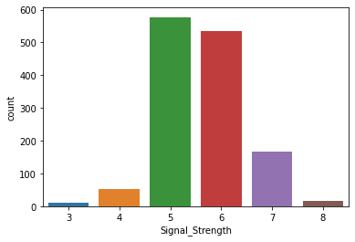

```python
sns.countplot(x='Signal_Strength', data=df)
```

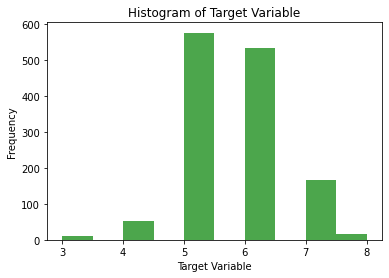

```python
#Visualise distribution of the target variable
target = df['Signal_Strength']
plt.hist(target, color='green', alpha=0.7)
plt.xlabel('Target Variable')
plt.ylabel('Frequency')
plt.title('Histogram of Target Variable')
plt.show()
```

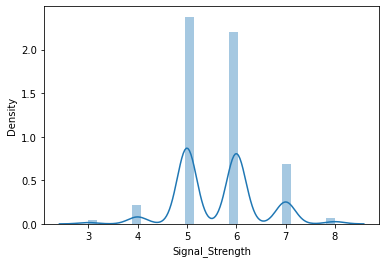

```python
sns.distplot(df['Signal_Strength'])
```

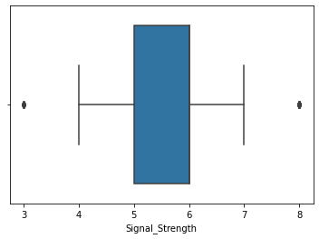

```python
sns.boxplot(x ='Signal_Strength', data = df)
```

### Q1E Share insights from the initial data analysis (at least 2). [2 Marks]

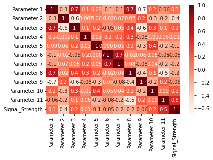

```python
sns.heatmap(df.corr(),annot=True, fmt='0.1g', cmap='Reds')
```

Insights from the initial data analysis 1.There are no null values in the data' 2.There are 240 duplicate values 3.Signal_Strength is highly positively correlated with Parameter 11 i.e. 0.5 4.Signal_Strength is highly negetively correlated with Parameter 2 i.e. -0.4 5.It means these two parameters will affect the Signal_Strength most in compare of other parameters 6.Most Signal_Strength is lie between range 5 and 6

## Q2. Data preprocessing [7 Marks]

### Q2A Split the data into X & Y. [1 Marks]

```python
#Split the data into X & Y.
X = df.iloc[:,0:11]
Y = df.iloc[:,-1]
```

```python
# all columns expect Signal_Strength
X
```

|  | Parameter 1 | Parameter 2 | Parameter 3 | Parameter 4 | Parameter 5 | Parameter 6 | Parameter 7 | Parameter 8 | Parameter 9 | Parameter 10 | Parameter 11 |
| --- | --- | --- | --- | --- | --- | --- | --- | --- | --- | --- | --- |
| 0 | 7.4 | 0.700 | 0.00 | 1.9 | 0.076 | 11.0 | 34.0 | 0.99780 | 3.51 | 0.56 | 9.4 |
| 1 | 7.8 | 0.880 | 0.00 | 2.6 | 0.098 | 25.0 | 67.0 | 0.99680 | 3.20 | 0.68 | 9.8 |
| 2 | 7.8 | 0.760 | 0.04 | 2.3 | 0.092 | 15.0 | 54.0 | 0.99700 | 3.26 | 0.65 | 9.8 |
| 3 | 11.2 | 0.280 | 0.56 | 1.9 | 0.075 | 17.0 | 60.0 | 0.99800 | 3.16 | 0.58 | 9.8 |
| 5 | 7.4 | 0.660 | 0.00 | 1.8 | 0.075 | 13.0 | 40.0 | 0.99780 | 3.51 | 0.56 | 9.4 |
| ... | ... | ... | ... | ... | ... | ... | ... | ... | ... | ... | ... |
| 1593 | 6.8 | 0.620 | 0.08 | 1.9 | 0.068 | 28.0 | 38.0 | 0.99651 | 3.42 | 0.82 | 9.5 |
| 1594 | 6.2 | 0.600 | 0.08 | 2.0 | 0.090 | 32.0 | 44.0 | 0.99490 | 3.45 | 0.58 | 10.5 |
| 1595 | 5.9 | 0.550 | 0.10 | 2.2 | 0.062 | 39.0 | 51.0 | 0.99512 | 3.52 | 0.76 | 11.2 |
| 1597 | 5.9 | 0.645 | 0.12 | 2.0 | 0.075 | 32.0 | 44.0 | 0.99547 | 3.57 | 0.71 | 10.2 |
| 1598 | 6.0 | 0.310 | 0.47 | 3.6 | 0.067 | 18.0 | 42.0 | 0.99549 | 3.39 | 0.66 | 11.0 |

1359 rows × 11 columns

```python
# Signal_Strength
Y
```

```
0       5
1       5
2       5
3       6
5       5
       ..
1593    6
1594    5
1595    6
1597    5
1598    6
Name: Signal_Strength, Length: 1359, dtype: int64
```

### Q2B Split the data into train & test with 70:30 proportion [1 Marks]

```python
#Spliting the data into train & test with 70:30 proportion
X_train, X_test, Y_train, Y_test = train_test_split(X, Y, test_size=0.3, random_state=40)
```

```python
X_train.shape
```

```
(951, 11)
```

```python
X_test.shape
```

```
(408, 11)
```

### Q2C Print shape of all the 4 variables and verify if train and test data is in sync. [1 Marks]

```python
# Print shape of all the 4 variables
print("Shape of X_train: ", X_train.shape)
print("Shape of X_test: ", X_test.shape)
print("Shape of Y_train: ", Y_train.shape)
print("Shape of Y_test: ", Y_test.shape)
# verify if train and test data is in sync
if X_train.shape[0] == Y_train.shape[0] and X_test.shape[0] == Y_test.shape[0]:
    print("Train and test data is in sync")
else:
    print("Train and test data is not in sync")
```

```
Shape of X_train:  (951, 11)
Shape of X_test:  (408, 11)
Shape of Y_train:  (951,)
Shape of Y_test:  (408,)
Train and test data is in sync
```

### Q2D Normalise the train and test data with appropriate method. [2 Marks]

```python
nxtrain = X_train
nxtest = X_test
nytrain = Y_train
nytest = Y_test


# Normalize train data

# from sklearn.preprocessing import Normalizer

from sklearn import preprocessing

xtest_no_zer = preprocessing.Normalizer().fit(nxtrain)
xtrain_no_zer = preprocessing.Normalizer().fit(nxtest)

nxtrain = xtest_no_zer.transform(nxtrain)
nxtrain

nxtest = xtest_no_zer.transform(nxtest)
nxtest
```

```
array([[0.1917607 , 0.00484244, 0.00891009, ..., 0.06159586, 0.01607691,
        0.20531954],
       [0.33841468, 0.01476064, 0.01728075, ..., 0.12024522, 0.02844123,
        0.43921905],
       [0.17889888, 0.01302851, 0.00194455, ..., 0.0643647 , 0.01050059,
        0.18473254],
       ...,
       [0.31521954, 0.01227697, 0.01725412, ..., 0.10551559, 0.01692231,
        0.31521954],
       [0.34379649, 0.02372196, 0.00378176, ..., 0.09901339, 0.01615843,
        0.33348259],
       [0.09435776, 0.00391239, 0.00425761, ..., 0.03716775, 0.00932071,
        0.13808452]])
```

```python
# Normalize train data
train_datay = Y_train
min_ytrain = np.min(train_datay, axis=0)
max_ytrain = np.max(train_datay, axis=0)
nytrain = (train_datay - min_ytrain) / (max_ytrain - min_ytrain)

# Normalize test data using the same min and max values from the train data
test_datay = Y_test
nytest = (test_datay - min_ytrain) / (max_ytrain - min_ytrain)
nytest
```

```
844     0.6
606     0.8
765     0.6
659     0.2
94      0.2
       ...
569     0.6
221     0.4
392     0.4
1470    0.4
1217    0.6
Name: Signal_Strength, Length: 408, dtype: float64
```

### Q2E Transform Labels into format acceptable by Neural Network [2 Marks]

Label Encoding

E. Transform Labels into format acceptable by Neural Network

```python
from sklearn.preprocessing import LabelEncoder
lbl_en = LabelEncoder()
```

```python
lbl_nytrain = lbl_en.fit_transform(nytrain)
lbl_nytrain
```

```
array([3, 1, 4, 2, 3, 2, 3, 2, 3, 2, 3, 3, 3, 4, 3, 4, 3, 2, 2, 3, 2, 2,
       2, 4, 4, 2, 3, 3, 3, 1, 3, 3, 2, 3, 2, 3, 3, 2, 4, 3, 3, 3, 3, 2,
       2, 3, 4, 3, 3, 3, 4, 2, 3, 2, 2, 3, 3, 1, 2, 2, 3, 3, 3, 2, 4, 3,
       5, 3, 2, 4, 3, 3, 2, 2, 2, 2, 3, 1, 2, 2, 1, 1, 3, 2, 2, 4, 2, 3,
       3, 2, 3, 2, 4, 3, 2, 2, 2, 3, 2, 2, 3, 3, 2, 3, 3, 2, 3, 2, 3, 3,
       2, 2, 3, 3, 2, 2, 3, 2, 3, 2, 4, 5, 0, 3, 4, 4, 2, 3, 3, 2, 3, 1,
       2, 5, 3, 2, 3, 3, 2, 2, 3, 4, 3, 3, 3, 3, 4, 2, 4, 1, 2, 4, 5, 4,
       2, 3, 2, 2, 3, 2, 3, 3, 2, 3, 3, 4, 3, 3, 2, 4, 1, 2, 3, 1, 3, 2,
       2, 4, 1, 4, 2, 2, 3, 4, 1, 3, 3, 2, 2, 2, 2, 2, 2, 2, 2, 3, 2, 4,
       2, 3, 2, 1, 4, 2, 4, 3, 3, 2, 3, 3, 2, 4, 3, 2, 4, 3, 3, 0, 2, 4,
       2, 3, 2, 3, 3, 3, 4, 2, 2, 2, 3, 3, 2, 0, 3, 3, 2, 4, 4, 3, 3, 3,
       2, 2, 2, 3, 2, 2, 2, 3, 3, 2, 3, 3, 3, 2, 3, 2, 3, 3, 3, 4, 3, 2,
       2, 3, 2, 4, 2, 3, 4, 4, 1, 2, 3, 2, 1, 3, 3, 3, 4, 2, 4, 3, 2, 2,
       2, 2, 2, 2, 2, 2, 4, 3, 3, 2, 2, 0, 3, 2, 2, 2, 3, 2, 2, 2, 3, 2,
       2, 3, 2, 2, 2, 2, 4, 2, 3, 2, 2, 4, 1, 3, 3, 2, 2, 2, 3, 2, 2, 3,
```

[output cut: 29 more lines]

```python
lbl_nytest = lbl_en.fit_transform(nytest)
lbl_nytest
```

```
array([3, 4, 3, 1, 1, 3, 2, 3, 3, 2, 3, 2, 2, 2, 4, 2, 0, 3, 2, 1, 2, 2,
       2, 2, 2, 2, 3, 3, 2, 2, 3, 2, 2, 2, 2, 2, 2, 3, 2, 4, 2, 4, 1, 3,
       2, 0, 2, 2, 2, 0, 3, 1, 3, 3, 2, 3, 3, 3, 2, 4, 4, 3, 2, 3, 3, 3,
       3, 2, 2, 3, 3, 4, 3, 4, 2, 2, 3, 3, 3, 2, 2, 3, 3, 2, 3, 4, 3, 3,
       2, 4, 2, 3, 3, 3, 3, 2, 2, 4, 3, 2, 3, 2, 3, 2, 3, 2, 3, 3, 3, 3,
       4, 4, 3, 4, 2, 4, 3, 4, 3, 3, 2, 2, 2, 2, 3, 2, 4, 3, 2, 2, 3, 4,
       2, 3, 3, 3, 4, 3, 2, 1, 3, 4, 2, 2, 2, 3, 3, 5, 3, 3, 1, 3, 3, 2,
       4, 2, 3, 2, 3, 3, 3, 3, 2, 3, 2, 3, 3, 2, 3, 3, 4, 3, 4, 5, 4, 3,
       4, 2, 2, 4, 1, 4, 2, 1, 3, 2, 1, 2, 2, 2, 3, 3, 2, 3, 4, 3, 2, 2,
       2, 3, 2, 2, 2, 2, 2, 2, 3, 3, 3, 4, 2, 1, 3, 4, 2, 2, 2, 2, 2, 1,
       3, 4, 2, 4, 2, 4, 3, 3, 3, 3, 2, 4, 2, 4, 3, 2, 2, 2, 2, 3, 3, 3,
       1, 2, 2, 2, 3, 2, 3, 3, 3, 2, 2, 3, 2, 3, 3, 4, 2, 2, 2, 3, 2, 3,
       3, 5, 4, 3, 2, 2, 2, 3, 4, 4, 4, 4, 4, 3, 3, 3, 3, 3, 3, 3, 2, 2,
       3, 3, 2, 4, 2, 3, 2, 0, 3, 3, 3, 3, 3, 3, 3, 3, 2, 2, 2, 2, 2, 3,
       2, 2, 3, 3, 3, 2, 2, 2, 2, 2, 4, 3, 3, 2, 2, 2, 5, 2, 3, 2, 2, 4,
       3, 2, 4, 2, 2, 3, 3, 3, 5, 4, 2, 3, 3, 2, 3, 4, 4, 2, 2, 5, 2, 3,
       2, 2, 3, 2, 3, 2, 3, 3, 4, 3, 2, 2, 3, 3, 3, 3, 3, 2, 2, 2, 2, 3,
       3, 3, 3, 2, 3, 3, 3, 2, 3, 2, 3, 2, 2, 3, 3, 2, 2, 3, 1, 2, 3, 3,
       2, 1, 2, 2, 3, 2, 2, 3, 2, 2, 2, 3])
```

## Q3 Model Training & Evaluation using Neural Network [13 Marks]

### Q3A Design a Neural Network to train a classifier. [3 Marks]

```python
nytest
```

```
844     0.6
606     0.8
765     0.6
659     0.2
94      0.2
       ...
569     0.6
221     0.4
392     0.4
1470    0.4
1217    0.6
Name: Signal_Strength, Length: 408, dtype: float64
```

```python
# Prepare the data

X_train
# Define the architecture
model = keras.Sequential([keras.layers.Dense(9, input_shape=(11,), activation =  'sigmoid')])

# Compile the model
model.compile(optimizer='adam', loss='sparse_categorical_crossentropy', metrics=['accuracy'])
```

[output not shown]

```python
# Train the model
#model.fit(X_trainQ, Y_trainQ, epochs=100, batch_size=1)
# model.fit(nxtrain, nytrain, epochs =5, batch_size=2)
history =  model.fit(X_train, Y_train, epochs=5, validation_data=(X_test, Y_test) )
```

```python
y_pred = model.predict(X_test)
y_pred[0].argmax()
```

```
5
```

```python
y_pred[0]
```

```
array([4.6343452e-01, 4.9796104e-03, 1.6264649e-10, 9.9980974e-01,
       2.8139442e-01, 1.0000000e+00, 1.0000000e+00, 1.0000000e+00,
       4.7945988e-01], dtype=float32)
```

```python
X_test.iloc[[0]]
```

|  | Parameter 1 | Parameter 2 | Parameter 3 | Parameter 4 | Parameter 5 | Parameter 6 | Parameter 7 | Parameter 8 | Parameter 9 | Parameter 10 | Parameter 11 |
| --- | --- | --- | --- | --- | --- | --- | --- | --- | --- | --- | --- |
| 844 | 9.9 | 0.25 | 0.46 | 1.7 | 0.062 | 26.0 | 42.0 | 0.9959 | 3.18 | 0.83 | 10.6 |

```python
df.loc[[844]]
```

|  | Parameter 1 | Parameter 2 | Parameter 3 | Parameter 4 | Parameter 5 | Parameter 6 | Parameter 7 | Parameter 8 | Parameter 9 | Parameter 10 | Parameter 11 | Signal_Strength |
| --- | --- | --- | --- | --- | --- | --- | --- | --- | --- | --- | --- | --- |
| 844 | 9.9 | 0.25 | 0.46 | 1.7 | 0.062 | 26.0 | 42.0 | 0.9959 | 3.18 | 0.83 | 10.6 | 6 |

```python
# # Evaluate the model
scores = model.evaluate(X_test, Y_test)
print("\n%s: %.2f%%" % (model.metrics_names[1], scores[1]*100))
```

```
accuracy: 46.08%
```

### Q3C Plot 2 separate visuals. [3 Marks]

### Q3C.(i) Training Loss and Validation Loss

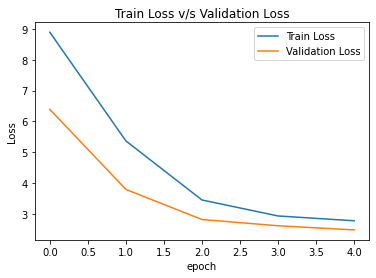

```python
plt.plot(history.history['loss'], label = 'Training Loss')
plt.plot(history.history['val_loss'], label = 'Validation Loss')
plt.title('Train Loss v/s Validation Loss')
plt.ylabel('Loss')
plt.xlabel('epoch')
plt.legend(['Train Loss', 'Validation Loss'], loc='upper right')
plt.show()
```

```python
test_loss, test_acc = model.evaluate(X_test, Y_test)
```

```python
print(test_loss)
print(test_acc)
```

```
2.4882678985595703
0.46078431606292725
```

### Q3C.(ii) Training Accuracy and Validation Accuracy

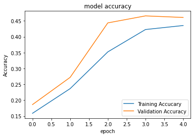

```python
plt.plot(history.history['accuracy'], label = 'Training Accuracy')
plt.plot(history.history['val_accuracy'], label = 'Validation Accuracy')
plt.title('model accuracy')
plt.ylabel('Accuracy')
plt.xlabel('epoch')
plt.legend(['Training Accucary', 'Validation Accuracy'], loc='lower right')
plt.show()
```

```python
# Prepare the data
# adding hidden layers to architecture

X_train
# Define the architecture
model = keras.Sequential([
        keras.layers.Dense(100, input_shape=(11,), activation = 'relu'), # hidden layer 1
        keras.layers.Dense(9,activation ='sigmoid' )])

# Compile the model
model.compile(optimizer='adam', loss='sparse_categorical_crossentropy', metrics=['accuracy'])
```

```python
# Train the model with adding one hidden layer
# model.fit(X_train, Y_train, epochs = 10, batch_size=5)
history =  model.fit(X_train, Y_train, epochs=15, batch_size=5,  validation_data=(X_test, Y_test) )
```

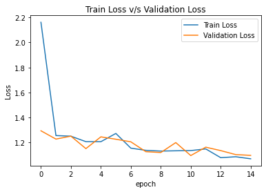

```python
plt.plot(history.history['loss'], label = 'Training Loss')
plt.plot(history.history['val_loss'], label = 'Validation Loss')
plt.title('Train Loss v/s Validation Loss')
plt.ylabel('Loss')
plt.xlabel('epoch')
plt.legend(['Train Loss', 'Validation Loss'], loc='upper right')
plt.show()
```

### Q3(ii)

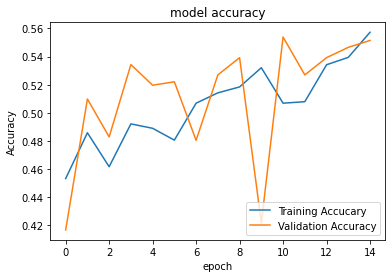

```python
plt.plot(history.history['accuracy'], label = 'Training Accuracy')
plt.plot(history.history['val_accuracy'], label = 'Validation Accuracy')
plt.title('model accuracy')
plt.ylabel('Accuracy')
plt.xlabel('epoch')
plt.legend(['Training Accucary', 'Validation Accuracy'], loc='lower right')
plt.show()
```

# PART B

## Q1. Data Import and Exploration [5 Marks]

```python
from keras.layers import Dense, Dropout, Flatten, Conv2D, MaxPooling2D
# from keras.callbacks import ModelCheckpoint, EarlyStopping
```

### Q1A Read the .h5 file and assign to a variable. [2 Marks]

```python
import h5py
import numpy as np
h5f = h5py.File('Desktop/data/Autonomous_Vehicles_SVHN_single_grey1.h5', 'r')
h5f
```

```
<HDF5 file "Autonomous_Vehicles_SVHN_single_grey1.h5" (mode r)>
```

### Q1B Print all the keys from the .h5 file. [1 Marks]

```python
for i in h5f.keys():
    print(i)
```

```
X_test
X_train
X_val
y_test
y_train
y_val
```

### Q1C Split the data into X_train, X_test, Y_train, Y_test [2 Marks]

```python
x_train = h5f['X_train'][:]
y_train = h5f['y_train'][:]
x_test = h5f['X_test'][:]
y_test = h5f['y_test'][:]
```

```python
# Close the h5 file
h5f.close()
```

## Q2 Data Visualisation and preprocessing [13 Marks]

### Q2A Print shape of all the 4 data split into x, y, train, test to verify if x & y is in sync. [1 Marks]

```python
print('X_train:', x_train.shape)
print('y_train:', y_train.shape)
print('X_test:', x_train.shape)
print('y_test:', y_train.shape)
```

[output not shown]

```python
if len(x_train)==len(y_train) and len(x_test)==len(y_test):
    print('x_train and y_train is in sync.')
    print('x_test and y_test is in sync.')
else:
    print('x_train and y_train is not in sync.')
```

```
x_train and y_train is in sync.
x_test and y_test is in sync.
```

### Q2B Visualise first 10 images in train data and print its corresponding labels. [4 Marks]

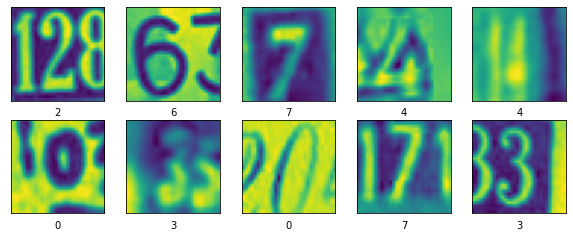

```python
import matplotlib.pyplot as plt
%matplotlib inline

plt.figure(figsize=(10,10))
for i in range(10):
  plt.subplot(5,5,i+1)
  plt.xticks([])
  plt.yticks([])
  plt.grid([])
  plt.imshow(x_train[i])
  plt.xlabel(y_train[i])
plt.show()
```

### Q2C Reshape all the images with appropriate shape update the data in same variable. [3 Marks]

```python
print('Shape of x_train Before reshape ==>',x_train.shape) #before reshape

# 3D ===> 2D

x_rs_train = x_train.reshape(len(x_train),32 * 32)
x_rs_test = x_test.reshape(x_test.shape[0], 32 * 32)
print('Shape of x_train after reshape ==>',x_rs_train.shape)
print('Shape of x_test after reshape ==>',x_rs_test.shape)
print(x_rs_test.ndim)
```

```
Shape of x_train Before reshape ==> (42000, 32, 32)
Shape of x_train after reshape ==> (42000, 1024)
Shape of x_test after reshape ==> (18000, 1024)
2
```

```python
len(x_train)
```

```
42000
```

```python
x_rs_train[0]
```

```
array([33.0704, 30.2601, 26.852 , ..., 49.6682, 50.853 , 53.0377],
      dtype=float32)
```

### Q2D Normalise the images i.e. Normalise the pixel values. [2 Marks]

```python
#Normalizing the input
x_nrml_train = x_rs_train / 255.0
x_nrml_test = x_rs_test / 255.0

print(f'Max of x_test ==> {x_nrml_train.max():.4f}')
print(f'Min of x_test ==> {x_nrml_train.min()}')

print(x_nrml_train.shape)
```

```
Max of x_test ==> 0.9999
Min of x_test ==> 0.0
(42000, 1024)
```

```python
y_train.shape
```

```
(42000,)
```

### Q2E Transform Labels into format acceptable by Neural Network [2 Marks]

```python
from keras.utils import np_utils
keras.utils.np_utils.to_categorical
```

```
<function keras.utils.np_utils.to_categorical(y, num_classes=None, dtype='float32')>
```

```python
#convert class vectors to binary class metrics
# num_classes = 10 since we will only classify nos between 0-9
cat_y_train = keras.utils.np_utils.to_categorical(y_train, 10 )

cat_y_test = keras.utils.np_utils.to_categorical(y_test,len(np.unique(y_test)))
cat_y_train[0]
cat_y_train.shape
```

```
(42000, 10)
```

```python
df_cat_y_train = pd.DataFrame(cat_y_train)
```

```python
list(df_cat_y_train.columns)
```

```
[0, 1, 2, 3, 4, 5, 6, 7, 8, 9]
```

### Q2F Print total Number of classes in the Dataset. [1 Marks]

```python
# To check the total number of Class in y_train
print(f'All of classes in y_train ==> {np.unique(y_train)}')
print(f'Total number of classes in y_train ==> {len(np.unique(y_train))}')
```

```
All of classes in y_train ==> [0 1 2 3 4 5 6 7 8 9]
Total number of classes in y_train ==> 10
```

## Q3 Model Training & Evaluation using Neural Network [12 Marks]

### Q3A Design a Neural Network to train a classifier. [3 Marks]

```python
print(x_nrml_train.shape)
print(x_nrml_test.shape)
print(cat_y_train.shape)
print(cat_y_test.shape)
print(y_train.shape)
```

```
(42000, 1024)
(18000, 1024)
(42000, 10)
(18000, 10)
(42000,)
```

```python
# DATA

x_nrml_train
x_nrml_test

cat_y_train
cat_y_test

model= keras.Sequential([
    keras.layers.Dense(10, input_shape=(1024,), activation='sigmoid')
    ])


model.compile(optimizer='adam',
              loss='sparse_categorical_crossentropy',
              metrics=['accuracy'])

history = model.fit(x_nrml_train, y_train, epochs=10, batch_size = 20, validation_data = (x_nrml_test, y_test))


# model_ANN.add(Dense(10, activation = 'softmax')) #output layer
model.summary()
```

```
Model: "sequential_2"
_________________________________________________________________
 Layer (type)                Output Shape              Param #
=================================================================
 dense_3 (Dense)             (None, 10)                10250

=================================================================
Total params: 10,250
Trainable params: 10,250
Non-trainable params: 0
_________________________________________________________________
```

```python
model.evaluate(x_nrml_test, y_test)
```

```
[2.314666271209717, 0.15727777779102325]
```

```python
y_predicted = model.predict(x_nrml_test)
y_predicted[0]
```

```
array([0.449132  , 0.45404536, 0.5777707 , 0.49578497, 0.5087965 ,
       0.46012193, 0.4278739 , 0.51616055, 0.45986778, 0.6171557 ],
      dtype=float32)
```

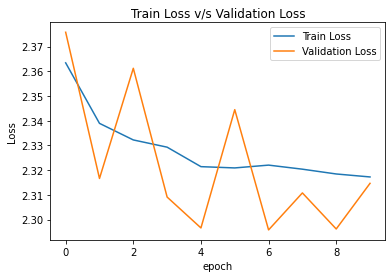

```python
plt.plot(history.history['loss'], label = 'Training Loss')
plt.plot(history.history['val_loss'], label = 'Validation Loss')
plt.title('Train Loss v/s Validation Loss')
plt.ylabel('Loss')
plt.xlabel('epoch')
plt.legend(['Train Loss', 'Validation Loss'], loc='upper right')
plt.show()
```

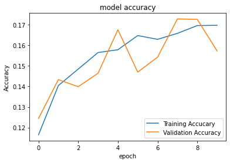

```python
plt.plot(history.history['accuracy'], label = 'Training Accuracy')
plt.plot(history.history['val_accuracy'], label = 'Validation Accuracy')
plt.title('model accuracy')
plt.ylabel('Accuracy')
plt.xlabel('epoch')
plt.legend(['Training Accucary', 'Validation Accuracy'], loc='lower right')
plt.show()
```

### Q3B Train the classifier using previously designed Architecture (Use best suitable parameters). [3 Marks]

```python
# DATA

x_nrml_train
x_nrml_test

cat_y_train
cat_y_test
def bulid_clf(ginp):
    u_model= keras.Sequential([
        keras.layers.Dense(ginp, input_shape=(1024,), activation='sigmoid'),
        keras.layers.Dense(50, activation='sigmoid'),
        keras.layers.Dense(10, activation='sigmoid')
        ])



    u_model.compile(optimizer='adam',
                loss='sparse_categorical_crossentropy',
                metrics=['accuracy'])

    return u_model

# u_history = u_model.fit(x_nrml_train, y_train, epochs=10, batch_size = 20, validation_data = (x_nrml_test, y_test) )


# model_ANN.add(Dense(10, activation = 'softmax')) #output layer
# u_model.summary()
```

```python
from keras.wrappers.scikit_learn import KerasClassifier

from sklearn.model_selection import GridSearchCV

keras_model = KerasClassifier(build_fn=bulid_clf, verbose = 1)
```

```python
param = { 'epochs' : [5,10],
        'batch_size': [15,20,],
        # 'optimizer':['adam'],
        'ginp':[20,30]
        }
grdsearch = GridSearchCV(estimator=keras_model, param_grid=param, cv=5, scoring='r2')
f_grd_search = grdsearch.fit(x_nrml_train, y_train, verbose =5)
```

```python
f_grd_search.best_params_
```

```
{'batch_size': 20, 'epochs': 10, 'ginp': 30}
```

```python
# DATA

x_nrml_train
x_nrml_test

cat_y_train
cat_y_test

u_model= keras.Sequential([
    keras.layers.Dense(100, input_shape=(1024,), activation='relu'),
    keras.layers.Dense(50, activation='sigmoid'),
    keras.layers.Dense(10, activation='sigmoid')
    ])



u_model.compile(optimizer='adam',
            loss='sparse_categorical_crossentropy',
            metrics=['accuracy'])



u_history = u_model.fit(x_nrml_train, y_train, epochs=10, batch_size = 20, validation_data = (x_nrml_test, y_test) )


# model_ANN.add(Dense(10, activation = 'softmax')) #output layer
u_model.summary()
```

```
Model: "sequential_44"
_________________________________________________________________
 Layer (type)                Output Shape              Param #
=================================================================
 dense_127 (Dense)           (None, 100)               102500

 dense_128 (Dense)           (None, 50)                5050

 dense_129 (Dense)           (None, 10)                510

=================================================================
Total params: 108,060
Trainable params: 108,060
Non-trainable params: 0
_________________________________________________________________
```

### Q3C Evaluate performance of the model with appropriate metrics. [2 Marks]

```python
u_model.evaluate(x_nrml_test, y_test)
```

```
[0.9468063116073608, 0.7085555791854858]
```

```python
y_predicted = u_model.predict(x_nrml_test)
y_predicted[9]
```

```
array([0.17446348, 0.4587789 , 0.28451693, 0.23216423, 0.9860392 ,
       0.27590042, 0.5444446 , 0.0857535 , 0.5001945 , 0.18872106],
      dtype=float32)
```

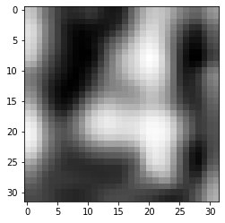

```python
plt.imshow(x_test[9], cmap='Greys')
```

```python
print(np.argmax(y_predicted[9]))
print(y_test[9])
```

```
4
4
```

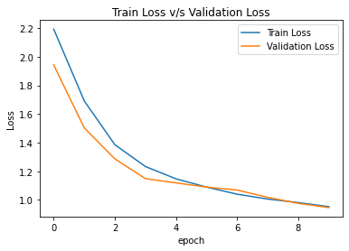

```python
plt.plot(u_history.history['loss'], label = 'Training Loss')
plt.plot(u_history.history['val_loss'], label = 'Validation Loss')
plt.title('Train Loss v/s Validation Loss')
plt.ylabel('Loss')
plt.xlabel('epoch')
plt.legend(['Train Loss', 'Validation Loss'], loc='upper right')
plt.show()
```

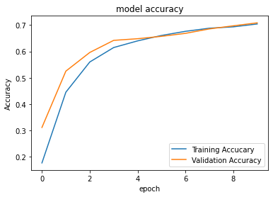

```python
plt.plot(u_history.history['accuracy'], label = 'Training Accuracy')
plt.plot(u_history.history['val_accuracy'], label = 'Validation Accuracy')
plt.title('model accuracy')
plt.ylabel('Accuracy')
plt.xlabel('epoch')
plt.legend(['Training Accucary', 'Validation Accuracy'], loc='lower right')
plt.show()
```